# Visualization Audit and Revision

## Plot question

This figure answers: How does the mean BMI compare across income groups over time in the classroom NHANES snapshot?

## Audit of the flawed starter

The flawed version was misleading in six ways:

1. The y-axis was cut off at 24 to 28, which visually inflated differences between income groups.
2. The title claimed a causal story: “Low income drives rising obesity,” even though the plot only summarized averages in a descriptive snapshot.
3. The subtitle described an age range that was not actually filtered in the code, so the sample was not clearly defined.
4. The plot did not explain that rows with missing BMI or IncomeGroup were excluded and that the figure is unweighted.
5. The timeline omitted the missing COVID cycle (2019-2020), which makes the series look continuous even though that year is absent from the dataset.
6. Treating cycles as equally spaced categories hides the longer gap between 2017-2018 and 2021-2023.

I corrected these by using a zero-based y-axis, an honest title, and a caption that states the statistic, exclusions, and descriptive limits. The x-axis uses cycle start years so the longer gap before 2021-2023 is visible, and the caption notes that 2019-2020 is not available in this snapshot.

## Corrected figure

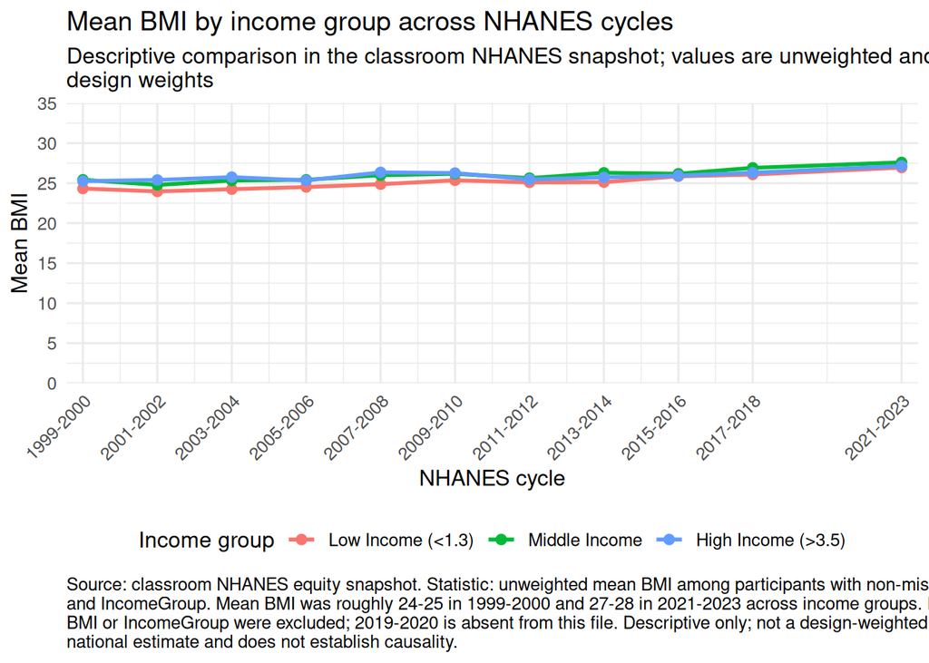

## Final caption

The plot reports the unweighted mean BMI by income group among participants with non-missing BMI and income-group values. Means are roughly 24-25 in 1999-2000 and 27-28 in 2021-2023; 2019-2020 is absent from this snapshot, and the descriptive comparison is not a design-weighted national estimate or evidence of causality.

## M1 connection

This standard matters for my M1 project because every plot should state the unit of analysis, the exclusions, and whether a summary is weighted or descriptive. That makes the figure easier for a target audience to interpret and reduces the risk of overclaiming beyond what the data can support.